# latihan-pertemuan5

Ravi Mahesa Pramudya

2023-09-26

```r
library(ggplot2)
library(tsibble)
library(tseries)
library(MASS)
library(readxl)
```

#input data

```r
Data_Suhu <- read_excel("C:/Users/Dell/Documents/SMT5/MPDW/ravimahesa/mpdw/Data Suhu Singapura 2010-2021.xlsx")
View(Data_Suhu)
dtsuhu.ts <- ts(Data_Suhu$Suhu)
summary(dtsuhu.ts)
```

```
##    Min. 1st Qu.  Median    Mean 3rd Qu.    Max.
##   25.50   27.20   27.49   27.51   27.95   29.17
```

### Plot *Time Series*

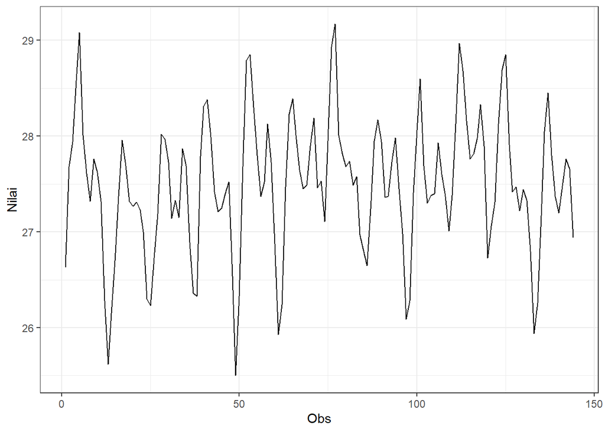

```r
plot_suhu <- dtsuhu.ts |> as_tsibble() |>
  ggplot(aes(x = index, y = value)) + geom_line() + theme_bw() +
  xlab("Obs") + ylab("Nilai")
plot_suhu
```

```r
mean(dtsuhu.ts)
```

```
## [1] 27.50528
```

Plot deret waktu di atas menunjukkan bahwa data stasioner dalam rataan, ditandai dengan data yang menyebar di sekitar nilai tengahnya (27) dan stasioner dalam ragam, ditandai dengan lebar pita yang cenderung sama.

### Plot ACF

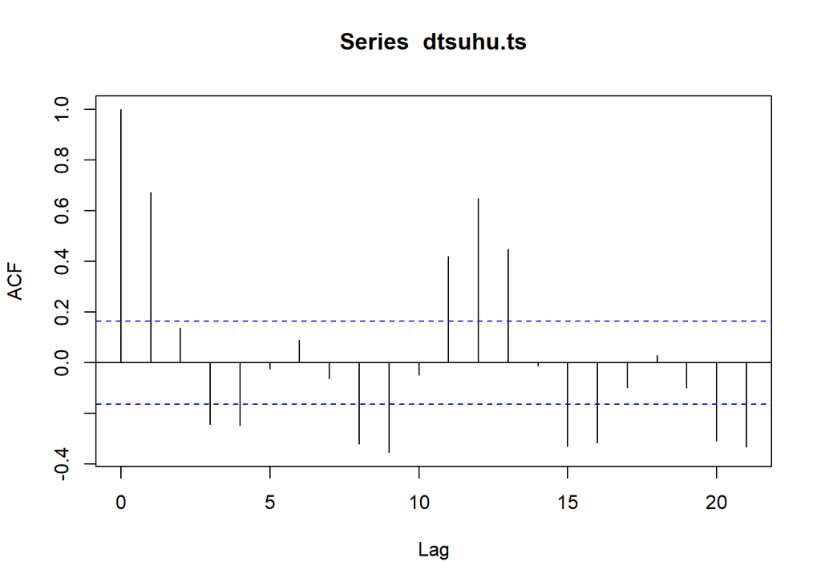

```r
acf(dtsuhu.ts)
```

Berdasarkan plot ACF, terlihat bahwa plot ACF pada data tersebut cenderung *tails off* dan membentuk gelombang sinus.

### Uji ADF

```r
tseries::adf.test(dtsuhu.ts)
```

```
##
##  Augmented Dickey-Fuller Test
##
## data:  dtsuhu.ts
## Dickey-Fuller = -5.727, Lag order = 5, p-value = 0.01
## alternative hypothesis: stationary
```

$H_0$ : Data tidak stasioner dalam rataan

$H_1$ : Data stasioner dalam rataan

Berdasarkan uji ADF tersebut, didapat *p-value* sebesar 0.01 yang lebih kecil dari taraf nyata 5% sehingga tolak $H_0$ dan menandakan bahwa data stasioner dalam rataan. Hal ini sesuai dengan hasil eksplorasi menggunakan plot time series dan plot ACF.

### Plot Box-Cox

```r
index <- seq(1:144)
bc = boxcox(dtsuhu.ts~index, lambda = seq(0,9,by=0.01))
```

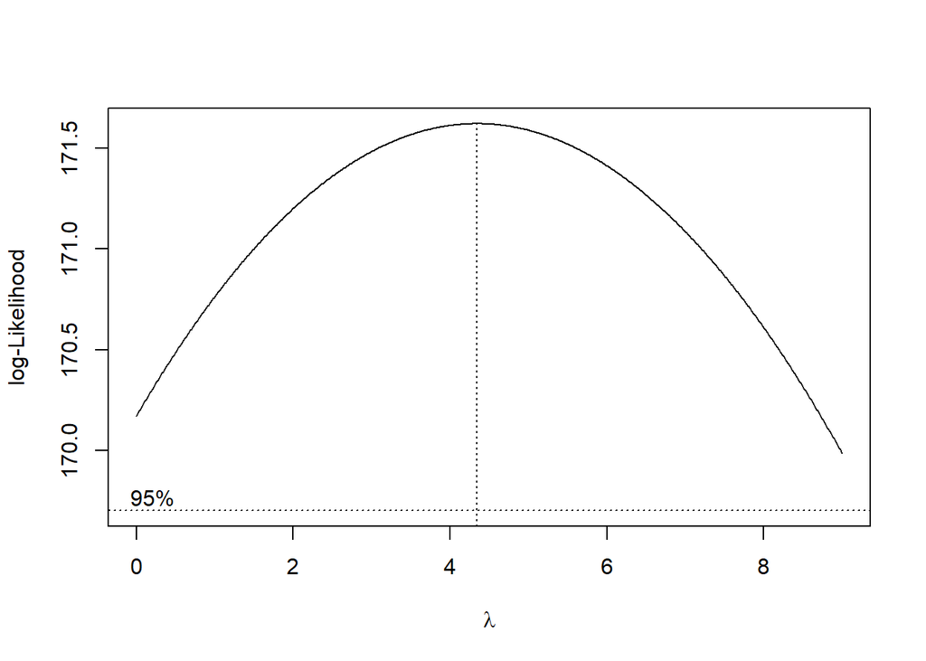

```r
#Nilai Rounded Lambda
lambda <- bc$x[which.max(bc$y)]
lambda
```

```
## [1] 4.34
```

```r
#SK
bc$x[bc$y > max(bc$y) - 1/2 * qchisq(.95,1)]
```

```
##   [1] 0.00 0.01 0.02 0.03 0.04 0.05 0.06 0.07 0.08 0.09 0.10 0.11 0.12 0.13 0.14
##  [16] 0.15 0.16 0.17 0.18 0.19 0.20 0.21 0.22 0.23 0.24 0.25 0.26 0.27 0.28 0.29
##  [31] 0.30 0.31 0.32 0.33 0.34 0.35 0.36 0.37 0.38 0.39 0.40 0.41 0.42 0.43 0.44
##  [46] 0.45 0.46 0.47 0.48 0.49 0.50 0.51 0.52 0.53 0.54 0.55 0.56 0.57 0.58 0.59
##  [61] 0.60 0.61 0.62 0.63 0.64 0.65 0.66 0.67 0.68 0.69 0.70 0.71 0.72 0.73 0.74
##  [76] 0.75 0.76 0.77 0.78 0.79 0.80 0.81 0.82 0.83 0.84 0.85 0.86 0.87 0.88 0.89
##  [91] 0.90 0.91 0.92 0.93 0.94 0.95 0.96 0.97 0.98 0.99 1.00 1.01 1.02 1.03 1.04
## [106] 1.05 1.06 1.07 1.08 1.09 1.10 1.11 1.12 1.13 1.14 1.15 1.16 1.17 1.18 1.19
## [121] 1.20 1.21 1.22 1.23 1.24 1.25 1.26 1.27 1.28 1.29 1.30 1.31 1.32 1.33 1.34
## [136] 1.35 1.36 1.37 1.38 1.39 1.40 1.41 1.42 1.43 1.44 1.45 1.46 1.47 1.48 1.49
## [151] 1.50 1.51 1.52 1.53 1.54 1.55 1.56 1.57 1.58 1.59 1.60 1.61 1.62 1.63 1.64
## [166] 1.65 1.66 1.67 1.68 1.69 1.70 1.71 1.72 1.73 1.74 1.75 1.76 1.77 1.78 1.79
## [181] 1.80 1.81 1.82 1.83 1.84 1.85 1.86 1.87 1.88 1.89 1.90 1.91 1.92 1.93 1.94
## [196] 1.95 1.96 1.97 1.98 1.99 2.00 2.01 2.02 2.03 2.04 2.05 2.06 2.07 2.08 2.09
## [211] 2.10 2.11 2.12 2.13 2.14 2.15 2.16 2.17 2.18 2.19 2.20 2.21 2.22 2.23 2.24
```

[output cut: 46 more lines]

Gambar di atas menunjukkan nilai *rounded value* ($\lambda$) optimum sebesar **4,34** dan pada selang kepercayaan 95% nilai memiliki batas bawah **0,00** dan batas atas *9,00**. Selang tersebut memuat nilai satu sehingga dapat dikatakan bahwa data bangkitan stasioner dalam ragam.

### Partisi Data

#### Bagian 1

```r
dt_suhu1 <- Data_Suhu$Suhu[1:67] |> ts()
mean(dt_suhu1)
```

```
## [1] 27.38791
```

```r
var(dt_suhu1)
```

```
## [1] 0.5934531
```

#### Plot Time Series

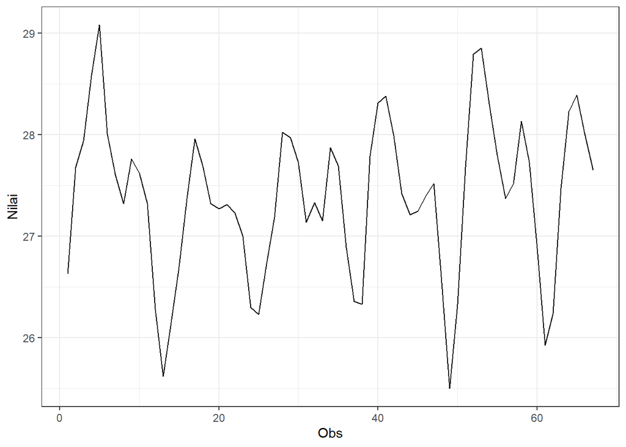

```r
dt_suhu1 |> as_tsibble() |>
  ggplot(aes(x = index, y = value)) +
  geom_line() + theme_bw() +
  xlab("Obs") + ylab("Nilai")
```

Plot deret waktu di atas menunjukkan bahwa data stasioner dalam rataan, ditandai dengan data yang menyebar di sekitar nilai tengahnya (27) dan stasioner dalam ragam, ditandai dengan lebar pita yang cenderung sama.

#### Plot ACF

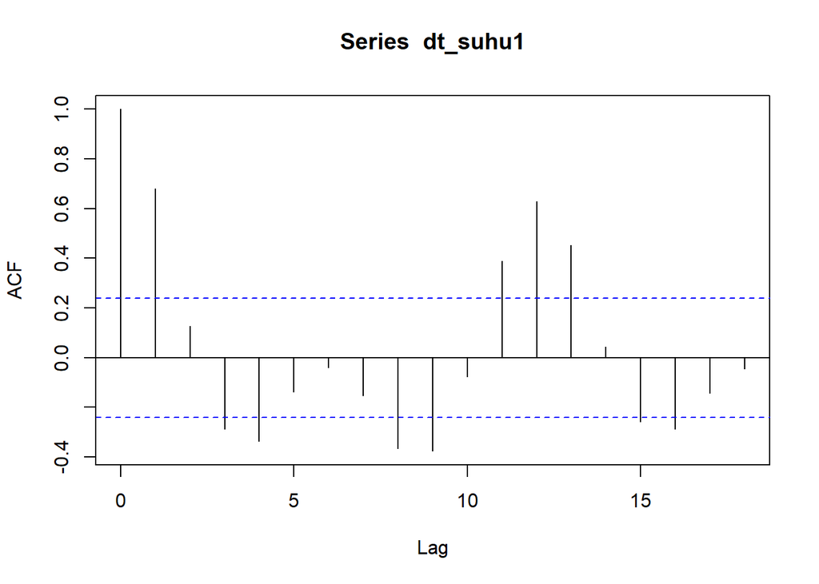

```r
acf(dt_suhu1)
```

Berdasarkan plot ACF, terlihat bahwa plot ACF pada data tersebut cenderung *tails off* dan membentuk gelombang sinus.

#### Uji ADF

```r
tseries::adf.test(dt_suhu1)
```

```
##
##  Augmented Dickey-Fuller Test
##
## data:  dt_suhu1
## Dickey-Fuller = -3.7645, Lag order = 4, p-value = 0.02612
## alternative hypothesis: stationary
```

$H_0$ : Data tidak stasioner dalam rataan

$H_1$ : Data stasioner dalam rataan

Berdasarkan uji ADF tersebut, didapat *p-value* sebesar 0.02612 yang lebih kecil dari taraf nyata 5% sehingga tolak $H_0$ dan menandakan bahwa data stasioner dalam rataan. Hal ini sesuai dengan hasil eksplorasi menggunakan plot time series dan plot ACF.

#### Plot Boxcox

```r
index1 <- seq(1:67)
bc1 = boxcox(dt_suhu1~index1, lambda = seq(-2,12,by=1))
```

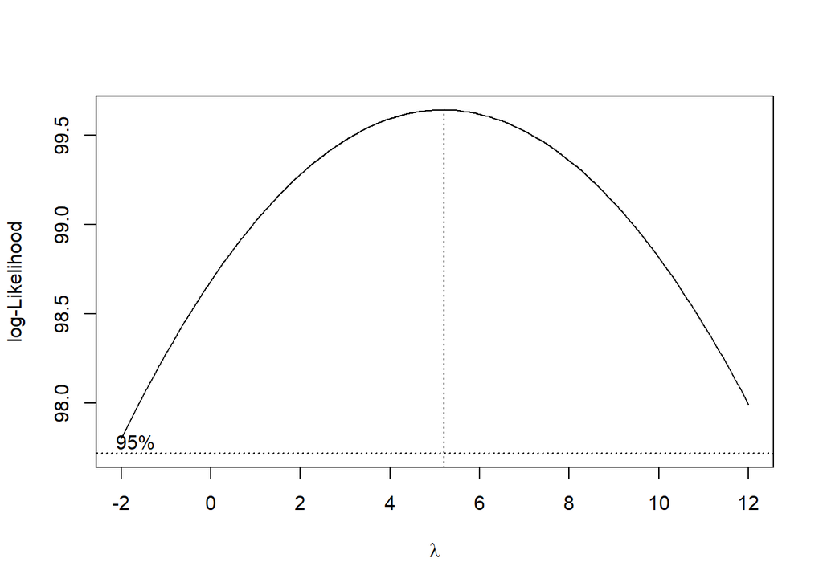

```r
#Nilai Rounded Lambda
lambda1 <- bc$x[which.max(bc$y)]
lambda1
```

```
## [1] 4.34
```

```r
#SK
bc1$x[bc1$y > max(bc1$y) - 1/2 * qchisq(.95,1)]
```

```
##   [1] -2.00000000 -1.85858586 -1.71717172 -1.57575758 -1.43434343 -1.29292929
##   [7] -1.15151515 -1.01010101 -0.86868687 -0.72727273 -0.58585859 -0.44444444
##  [13] -0.30303030 -0.16161616 -0.02020202  0.12121212  0.26262626  0.40404040
##  [19]  0.54545455  0.68686869  0.82828283  0.96969697  1.11111111  1.25252525
##  [25]  1.39393939  1.53535354  1.67676768  1.81818182  1.95959596  2.10101010
##  [31]  2.24242424  2.38383838  2.52525253  2.66666667  2.80808081  2.94949495
##  [37]  3.09090909  3.23232323  3.37373737  3.51515152  3.65656566  3.79797980
##  [43]  3.93939394  4.08080808  4.22222222  4.36363636  4.50505051  4.64646465
##  [49]  4.78787879  4.92929293  5.07070707  5.21212121  5.35353535  5.49494949
##  [55]  5.63636364  5.77777778  5.91919192  6.06060606  6.20202020  6.34343434
##  [61]  6.48484848  6.62626263  6.76767677  6.90909091  7.05050505  7.19191919
##  [67]  7.33333333  7.47474747  7.61616162  7.75757576  7.89898990  8.04040404
##  [73]  8.18181818  8.32323232  8.46464646  8.60606061  8.74747475  8.88888889
##  [79]  9.03030303  9.17171717  9.31313131  9.45454545  9.59595960  9.73737374
##  [85]  9.87878788 10.02020202 10.16161616 10.30303030 10.44444444 10.58585859
##  [91] 10.72727273 10.86868687 11.01010101 11.15151515 11.29292929 11.43434343
##  [97] 11.57575758 11.71717172 11.85858586 12.00000000
```

#### Bagian 2

```r
dt_suhu2 <- Data_Suhu$Suhu[1:125] |> ts()
mean(dt_suhu2)
```

```
## [1] 27.52872
```

```r
var(dt_suhu2)
```

```
## [1] 0.5229693
```

#### Plot Time Series

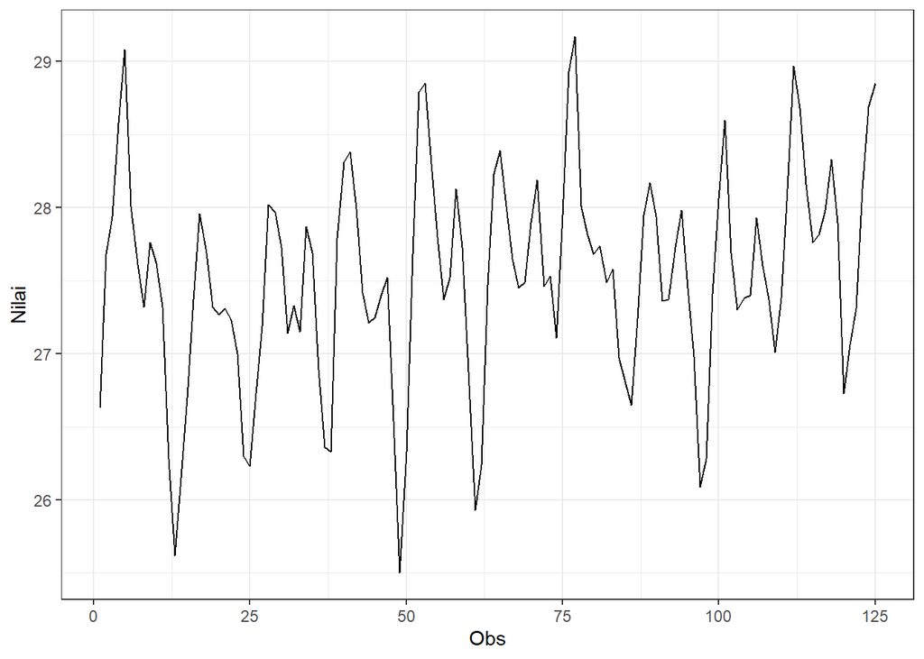

```r
dt_suhu2 |> as_tsibble() |>
  ggplot(aes(x = index, y = value)) +
  geom_line() + theme_bw() +
  xlab("Obs") + ylab("Nilai")
```

Plot deret waktu di atas menunjukkan bahwa data stasioner dalam rataan, ditandai dengan data yang menyebar di sekitar nilai tengahnya (27) dan stasioner dalam ragam, ditandai dengan lebar pita yang cenderung sama.

#### Plot ACF

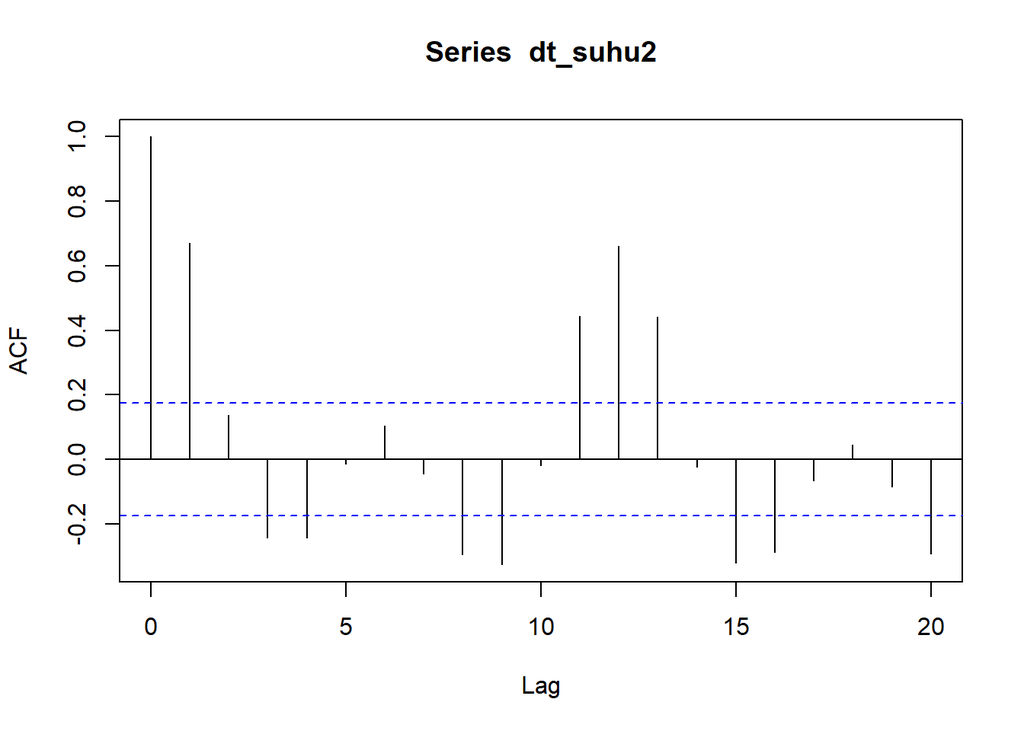

```r
acf(dt_suhu2)
```

Berdasarkan plot ACF, terlihat bahwa plot ACF pada data tersebut cenderung *tails off* dan membentuk gelombang sinus.

#### Uji ADF

```r
adf.test(dt_suhu2)
```

```
##
##  Augmented Dickey-Fuller Test
##
## data:  dt_suhu2
## Dickey-Fuller = -4.8139, Lag order = 4, p-value = 0.01
## alternative hypothesis: stationary
```

$H_0$ : Data tidak stasioner dalam rataan

$H_1$ : Data stasioner dalam rataan

Berdasarkan uji ADF tersebut, didapat *p-value* sebesar 0.01 yang lebih kecil dari taraf nyata 5% sehingga tolak $H_0$ dan menandakan bahwa data stasioner dalam rataan. Hal ini sesuai dengan hasil eksplorasi menggunakan plot time series dan plot ACF.

#### Plot Boxcox

```r
index2 <- seq(1:125)
bc2 = boxcox(dt_suhu2~index2, lambda = seq(0,9,by=1))
```

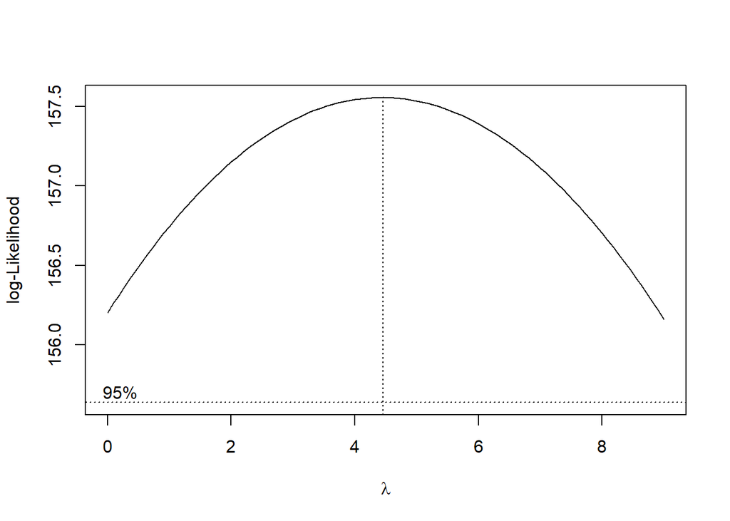

```r
#Nilai Rounded Lambda
lambda2 <- bc$x[which.max(bc$y)]
lambda2
```

```
## [1] 4.34
```

```r
#SK
bc2$x[bc2$y > max(bc2$y) - 1/2 * qchisq(.95,1)]
```

```
##   [1] 0.00000000 0.09090909 0.18181818 0.27272727 0.36363636 0.45454545
##   [7] 0.54545455 0.63636364 0.72727273 0.81818182 0.90909091 1.00000000
##  [13] 1.09090909 1.18181818 1.27272727 1.36363636 1.45454545 1.54545455
##  [19] 1.63636364 1.72727273 1.81818182 1.90909091 2.00000000 2.09090909
##  [25] 2.18181818 2.27272727 2.36363636 2.45454545 2.54545455 2.63636364
##  [31] 2.72727273 2.81818182 2.90909091 3.00000000 3.09090909 3.18181818
##  [37] 3.27272727 3.36363636 3.45454545 3.54545455 3.63636364 3.72727273
##  [43] 3.81818182 3.90909091 4.00000000 4.09090909 4.18181818 4.27272727
##  [49] 4.36363636 4.45454545 4.54545455 4.63636364 4.72727273 4.81818182
##  [55] 4.90909091 5.00000000 5.09090909 5.18181818 5.27272727 5.36363636
##  [61] 5.45454545 5.54545455 5.63636364 5.72727273 5.81818182 5.90909091
##  [67] 6.00000000 6.09090909 6.18181818 6.27272727 6.36363636 6.45454545
##  [73] 6.54545455 6.63636364 6.72727273 6.81818182 6.90909091 7.00000000
##  [79] 7.09090909 7.18181818 7.27272727 7.36363636 7.45454545 7.54545455
##  [85] 7.63636364 7.72727273 7.81818182 7.90909091 8.00000000 8.09090909
##  [91] 8.18181818 8.27272727 8.36363636 8.45454545 8.54545455 8.63636364
##  [97] 8.72727273 8.81818182 8.90909091 9.00000000
```

## Kesimpulan

**Data Full Suhu singapura pada tahun 2010-2021 merupakan data stasioner dalam rataan dan stasioner dalam ragam, Dan untuk data partisi bagian 1 dan juga partisi bagian 2 juga memiliki data yang stasioner dalam rataan dan juga stasioner dalam ragam**